# 2: Regression and model validation

### Instructions

> Describe the work you have done this week and summarize your learning.
> - Describe your work and results clearly.
> - Assume the reader has an introductory course level understanding of > writing and reading R code as well as statistical methods.
> - Assume the reader has no previous knowledge of your data or the more advanced methods you are using.

## **DATA WRANGLING**

Sections 2.0 – 2.6 produce a dataset named `data/learning2014.csv`. For statistical analysis, skip to **section 2.7**.

- 2.0– 2.6 Packages
- 2.1 Reading data from the web

### 2.0– 2.6 Packages

Let’s first load the required packages.

```r
# Packages
pacman::p_load(tidyverse, GGally, patchwork)

# Defining some custom functions
color_gender <- function () {scale_color_manual(values = rev(c("dodgerblue", "orangered")))}
fill_gender <- function () {scale_fill_manual(values = rev(c("dodgerblue", "orangered")))}
```

Reading data from:

```r
# Get data
lrn14 <- read.table("http://www.helsinki.fi/~kvehkala/JYTmooc/JYTOPKYS3-data.txt", sep = "\t", header = TRUE)

# Check dimensions
dim(lrn14)
```

```
## [1] 183  60
```

```r
# str(lrn14)
```

### Observations from the data:

- Looks like the `lrn14` dataset has 183 rows and 60 columns.
- Most columns appear to be intergers, whereas only `gender` is character.

### 2.2 Scaling variables

### Instructions

> - Execute the example codes to see how vectorized division works
> - Use vector division to create a new column `attitude` in the `lrn14` data frame, where each observation of `Attitude` is scaled back to the original scale of the questions, by dividing it with the number of questions.

> Hint: - Assign ‘Attitude divided by 10’ to the new column ’attitude.

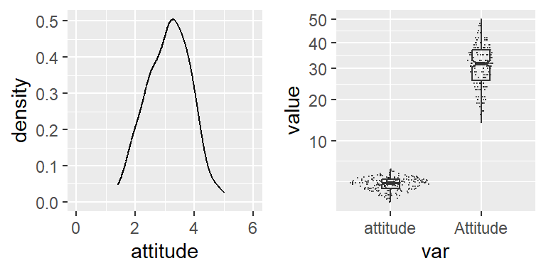

```r
# Scale the attitude variable to match other variables
lrn14 <- lrn14 %>%
  mutate(attitude = Attitude / 10)

# Check the distributions
ggpubr::ggarrange(
  # Density
  lrn14 %>% ggplot(aes(x = attitude)) + geom_density() +
    coord_cartesian(xlim = c(0, 6)),
  # Sina
  lrn14 %>%
    pivot_longer(
      cols = c(Attitude, attitude),
      names_to = "var",
      values_to = "value"
    ) %>% ggplot(aes(y = value, x = var)) +
    ggforce::geom_sina(size = .1, alpha = .5) +
    scale_y_sqrt() +
    geom_boxplot(width = .2, fill = NA, notch = T)
)
```

### 2.3 Combining variables

Computing row means for each class of questions in a for-loop.

### Instructions

> - Access the **dplyr** library
> - Execute the example codes to create the combination variables ‘deep’ and ‘surf’ as columns in `lrn14`
> - Select the columns related to strategic learning from `lrn14`
> - Create the combination variable ‘stra’ as a column in `lrn14`

> Hints: - Columns related to strategic learning are in the object `strategic_questions`. Use it for selecting the correct columns. - Use the function `rowMeans()` identically to the examples

```r
# Classify questions
deep <- c(
  "D03", "D11", "D19", "D27", "D07", "D14",
  "D22", "D30","D06",  "D15", "D23", "D31"
)
surf <- c(
  "SU02", "SU10", "SU18", "SU26", "SU05", "SU13",
  "SU21", "SU29", "SU08", "SU16", "SU24", "SU32"
)
stra <- c(
  "ST01", "ST09", "ST17", "ST25",
  "ST04", "ST12", "ST20", "ST28"
)

# Compute averages in a loop
for (Qclass in c("deep", "surf", "stra")) {
  lrn14[[Qclass]] <- rowMeans(lrn14[, get(Qclass)])
}

# Same thing, without creating new objects in the environment
# lrn14 <- lrn14 %>%
#   rowwise() %>%
#   mutate(
#     deep = mean(c( # Deep questions
#       D03, D11, D19, D27, D07, D14, D22, D30, D06, D15, D23, D31
#     )),
#     surf = mean(c( # Surface questions
#       SU02, SU10, SU18, SU26, SU05, SU13, SU21, SU29, SU08, SU16, SU24, SU32
#     )),
#     stra = mean(c( # Strategic questions
#       ST01, ST09, ST17, ST25, ST04, ST12, ST20, ST28
#     ))
#   ) %>% ungroup()
```

### 2.4 Selecting columns

Dropping individual question data and only keeping variables relevant for the analysis.

### Instructions

> - Access the **dplyr** library
> - Create object `keep_columns`
> - Use `select()` (possibly together with `one_of()`) to create a new data frame `learning2014` with the columns named in `keep_columns`.
> - Look at the structure of the new dataset

> Hint: - See the previous exercise or the data wrangling cheatsheet for help on how to select columns

```r
# Pick relevant vars
keep_columns <- c(
  "gender",
  "Age",
  "attitude",
  "deep",
  "stra",
  "surf",
  "Points"
)

# Drop useless vars
learning2014 <- lrn14 %>% select(
  all_of(keep_columns)
)

# See structure
str(learning2014)
```

```
## 'data.frame':    183 obs. of  7 variables:
##  $ gender  : chr  "F" "M" "F" "M" ...
##  $ Age     : int  53 55 49 53 49 38 50 37 37 42 ...
##  $ attitude: num  3.7 3.1 2.5 3.5 3.7 3.8 3.5 2.9 3.8 2.1 ...
##  $ deep    : num  3.58 2.92 3.5 3.5 3.67 ...
##  $ stra    : num  3.38 2.75 3.62 3.12 3.62 ...
##  $ surf    : num  2.58 3.17 2.25 2.25 2.83 ...
##  $ Points  : int  25 12 24 10 22 21 21 31 24 26 ...
```

### 2.5 Modifying column names

Changing all column names to include only lowercase letters.

```r
old_colnames <- colnames(learning2014)
learning2014 <- learning2014 %>%
  rename("age" = Age, "points" = Points)
new_colnames <- colnames(learning2014)

data.frame(old_colnames, new_colnames) %>% knitr::kable()
```

| old_colnames | new_colnames |
| --- | --- |
| gender | gender |
| Age | age |
| attitude | attitude |
| deep | deep |
| stra | stra |
| surf | surf |
| Points | points |

### 2.6 Excluding observations

Excluding students that did not attend the exam.

```r
# Filter non-attending students
learning2014 <- learning2014 %>%
  filter(points > 0)
```

### Write to file

Saving the processed minimal dataframe as a `.csv` file.

```r
# Write
readr::write_csv(learning2014, "data/learning2014.csv")
```

## Get data

### Instructions

> Read the students2014 data into R either from your local folder (if you completed the Data wrangling part) or from this url: https://raw.githubusercontent.com/KimmoVehkalahti/Helsinki-Open-Data-Science/master/datasets/learning2014.txt . (The separator is a comma “,” and the file includes a header). Explore the structure and the dimensions of the data and describe the dataset briefly, assuming the reader has no previous knowledge of it. There is information related to the data here. (0-2 points)

Reading in the `students2014.csv` dataset that was produced in the data wrangling part of the *Assignment 2*.

```r
# Get data
data <- readr::read_csv("data/learning2014.csv")
head(data); str(data)
```

```
## # A tibble: 6 × 7
##   gender   age attitude  deep  stra  surf points
##   <chr>  <dbl>    <dbl> <dbl> <dbl> <dbl>  <dbl>
## 1 F         53      3.7  3.58  3.38  2.58     25
## 2 M         55      3.1  2.92  2.75  3.17     12
## 3 F         49      2.5  3.5   3.62  2.25     24
## 4 M         53      3.5  3.5   3.12  2.25     10
## 5 M         49      3.7  3.67  3.62  2.83     22
## 6 F         38      3.8  4.75  3.62  2.42     21
```

```
## spc_tbl_ [166 × 7] (S3: spec_tbl_df/tbl_df/tbl/data.frame)
##  $ gender  : chr [1:166] "F" "M" "F" "M" ...
##  $ age     : num [1:166] 53 55 49 53 49 38 50 37 37 42 ...
##  $ attitude: num [1:166] 3.7 3.1 2.5 3.5 3.7 3.8 3.5 2.9 3.8 2.1 ...
##  $ deep    : num [1:166] 3.58 2.92 3.5 3.5 3.67 ...
##  $ stra    : num [1:166] 3.38 2.75 3.62 3.12 3.62 ...
##  $ surf    : num [1:166] 2.58 3.17 2.25 2.25 2.83 ...
##  $ points  : num [1:166] 25 12 24 10 22 21 21 31 24 26 ...
##  - attr(*, "spec")=
##   .. cols(
##   ..   gender = col_character(),
##   ..   age = col_double(),
##   ..   attitude = col_double(),
##   ..   deep = col_double(),
##   ..   stra = col_double(),
##   ..   surf = col_double(),
##   ..   points = col_double()
##   .. )
##  - attr(*, "problems")=<externalptr>
```

```r
# Plot data "missingness"
# Amelia::missmap(data)
# naniar::vis_miss(data)

# Summaries for numeric variables
do.call(cbind, lapply(data, summary)) %>%
  data.frame() %>% select(-gender) %>%
  mutate(across(1:6, \(x) as.numeric(x))) %>%
  mutate(across(1:6, \(x) round(x, 1))) %>%
  t() %>% knitr::kable() # DT::datatable()
```

|  | Min. | 1st Qu. | Median | Mean | 3rd Qu. | Max. |
| --- | --- | --- | --- | --- | --- | --- |
| age | 17.0 | 21.0 | 22.0 | 25.5 | 27.0 | 55.0 |
| attitude | 1.4 | 2.6 | 3.2 | 3.1 | 3.7 | 5.0 |
| deep | 1.6 | 3.3 | 3.7 | 3.7 | 4.1 | 4.9 |
| stra | 1.2 | 2.6 | 3.2 | 3.1 | 3.6 | 5.0 |
| surf | 1.6 | 2.4 | 2.8 | 2.8 | 3.2 | 4.3 |
| points | 7.0 | 19.0 | 23.0 | 22.7 | 27.8 | 33.0 |

```r
# Table gender
# table(data$gender, useNA = "always")
```

We are dealing with **complete data** with no missing values. Clearly, the four variables `attitude`, `deep`, `stra`, and `surf` represent averaged survey answers on a likert scale. Click here for more comprehensive [metadata](http://www.helsinki.fi/~kvehkala/JYTmooc/JYTOPKYS3-meta.txt).

## 2.7 Visualizations with ggplot2

### Instructions

> Show a graphical overview of the data and show summaries of the variables in the data. Describe and interpret the outputs, commenting on the distributions of the variables and the relationships between them. (0-3 points)

Let’s begin by checking the distributions of our dataset.

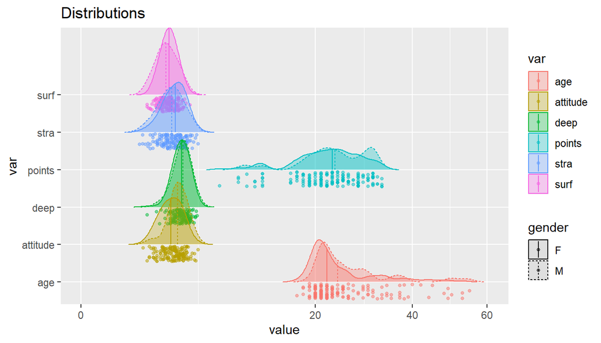

```r
p <- data %>% pivot_longer(
  cols = colnames(data)[-1],
  values_to = "value",
  names_to = "var"
) %>% ggplot(aes(x = value, color = var, fill = var, y = var, linetype = gender))#
p <- p + ggridges::geom_density_ridges(
  rel_min_height = .001, quantile_lines = T, quantiles = .5, jittered_points = TRUE,
  position = "raincloud", point_alpha = .5, point_size = 1, alpha = .3
)
# p <- p + theme(legend.position = "none")
p <- p + scale_x_sqrt(limits = c(0, NA))
p <- p + labs(title = "Distributions")
p
```

### Characteristics

`Age` and `gender`

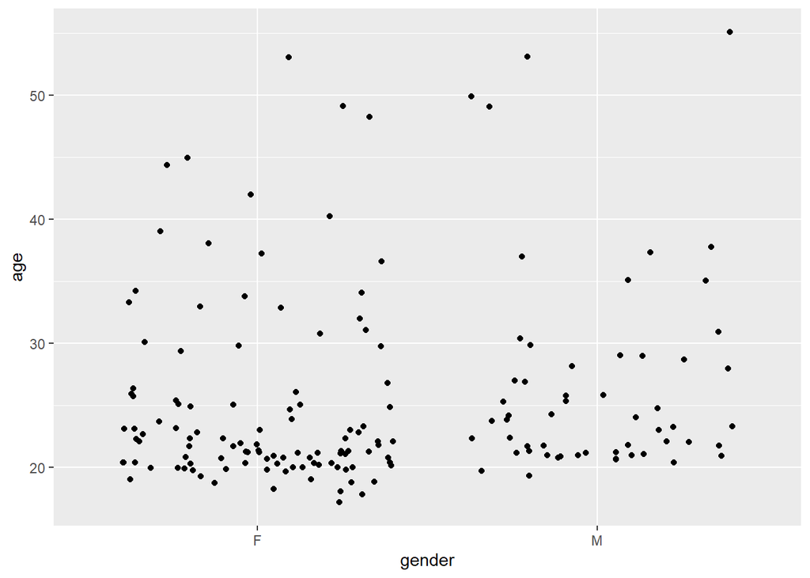

```r
p <- data %>% ggplot(aes(x = gender, y = age))
p <- p + geom_jitter()
p
```

### Predictors of exam `points`

There is plausibility that the `attitude` of the students or different learning strategies influence exam `points`. Therefore, let’s glance over these potential relationships:

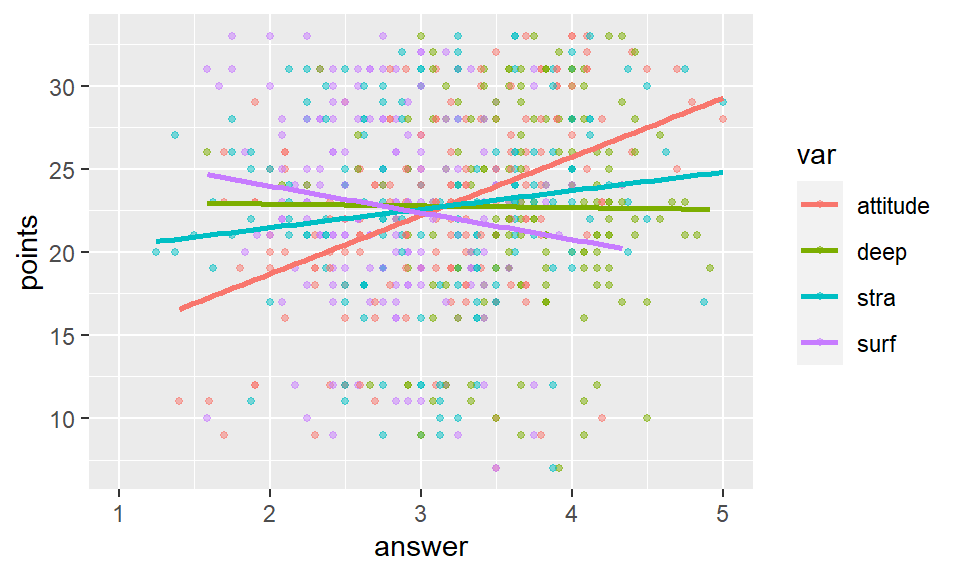

```r
p <- data %>% pivot_longer(
  cols = c(attitude, deep, stra, surf),
  values_to = "answer",
  names_to = "var"
) %>% ggplot(aes(x = answer, y = points, color = var))
p <- p + geom_point(alpha = .5, size = 1)
p <- p + geom_smooth(method = "lm", se = F)
p <- p + coord_cartesian(xlim = c(1, 5))
p
```

### Gender

This dataset also contains a variable called `gender`. It could be hypothesized that attitude, learning strategies and/or exam points differ between the genders.

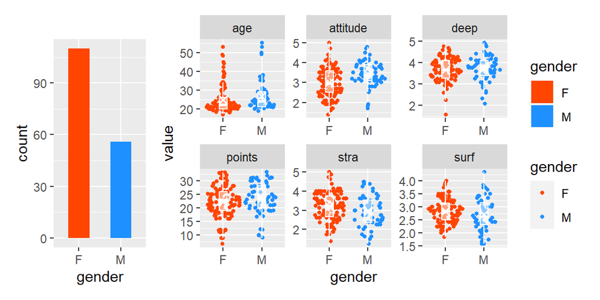

```r
p <- data %>% ggplot(aes(x = gender, fill = gender))
p <- p + geom_bar(width = .5)
p <- p + fill_gender()
p1 <- p

p <- data %>% pivot_longer(
  cols = colnames(data)[-1],
  values_to = "value",
  names_to = "var"
) %>% ggplot(aes(x = value, color = gender))#, linetype = gender
p <- p + geom_density()
# p <- p + scale_x_sqrt()
p <- p + facet_wrap(. ~ var, scales = "free")
p <- p + fill_gender()
p2 <- p

p <- data %>% pivot_longer(
  cols = colnames(data)[-1],
  values_to = "value",
  names_to = "var"
) %>% ggplot(aes(y = value, x = gender, color = gender))#, linetype = gender
p <- p + ggforce::geom_sina(size = 1)
p <- p + geom_boxplot(width = .2, color = "white", outlier.color = NA, alpha = .5)
p <- p + stat_summary(fun = mean, shape = 4, color = "white")
# p <- p + scale_x_sqrt()
p <- p + facet_wrap(. ~ var, scales = "free")
p <- p + color_gender()
p2 <- p

library(patchwork)
p1 + p2 + plot_layout(widths = c(.3, 1), guides = 'collect')
```

Perhaps `gender` modifies the relationship between learning strategies and exam points.

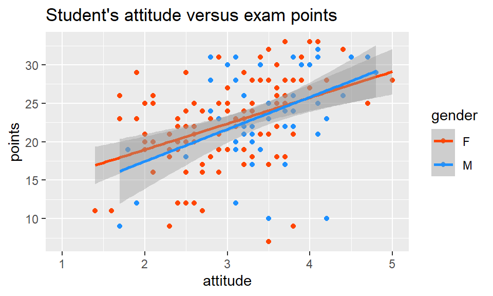

```r
p <- data %>%
  ggplot(aes(x = attitude, y = points, col = gender))
p <- p + geom_point()
p <- p + geom_smooth(method = "lm")
p <- p + ggtitle("Student's attitude versus exam points")
p <- p + coord_cartesian(xlim = c(1, 5))
p <- p + color_gender()
p
```

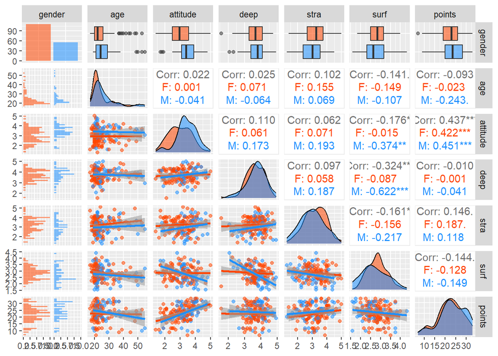

```r
# Visualize
# pairs(data[-1])
data %>% GGally::ggpairs(
  aes(col = gender, alpha = .3),
  lower = list(continuous = "smooth")
) +
  color_gender() + fill_gender()
```

## 2.8 Exploring a data frame

## 2.9 Simple regression

## 2.10 Multiple regression

## 2.11 Graphical model validation

## 2.12 Making predictions